# Chapter 12 environmental permanova

We test whether environmental α-diversity (Hill h0/h1/h2 of land-cover) relates to microbiome β-diversity (Bray–Curtis), and visualise relationships (e.g., NMDS axes vs. Hill metrics) and distance-matrix structure.

## 12.1 Load data

**Note:** Load all required data objects including sample metadata, beta diversity matrices, and Hill diversity metrics from the RData files created in previous chapters.

## 12.2 Data preparation

**Note:** Filter out sample EHI01340 from the metadata and Hill diversity data. This sample was removed because it could not be mapped to MAGs, ensuring consistency across downstream analyses.

```r
sample_metadata <- sample_metadata %>% dplyr::filter(sample != "EHI01340")
hill_long       <- hill_long       %>% dplyr::filter(id     != "EHI01340")
```

**Note:** Transform Hill diversity data from long to wide format, creating separate columns for each Hill diversity metric (env_hill_h0, env_hill_h1, env_hill_h2). Join with sample metadata to create a combined metadata object for downstream analyses.

## 12.3 Helper functions

**Note:** Helper function to align metadata with distance matrices. This eliminates code duplication when aligning metadata for multiple distance matrices. Defined early as it’s needed by multiple analysis sections.

**Note:** Optimized helper function that accepts pre-calculated NMDS object instead of recalculating. This eliminates redundant NMDS calculations when creating multiple plots.

## 12.4 Ordination analysis

**Note:** Extract distance matrices from beta diversity objects for use in ordination analyses. These matrices represent Bray-Curtis dissimilarities between samples at different diversity orders.

**Note:** Calculate all NMDS ordinations once upfront. These are expensive operations (trymax = 500 iterations each) and were previously calculated redundantly 3+ times. This optimization saves significant computation time.

**Note:** Align metadata with each distance matrix using the helper function. This ensures proper sample order matching for ordination and visualization.

[figure not shown]

## 12.5 Grouping variables

**Note:** Create grouping variables for environmental Hill diversity metrics. Calculate medians once to avoid redundant calculations. Split into tertiles (Low, Mid, High) and median-based groups (Low, High) for visualization and statistical testing.

```
 Low  Mid High
  30   22   20
```

```
High  Low
  33   39
```

## 12.6 PERMANOVA analysis

**Note:** Define function to run PERMANOVA tests for each environmental Hill diversity metric (h0, h1, h2) against beta diversity distance matrices. The function aligns metadata with distance matrix samples, ensures sample order matches, and performs PERMANOVA with 999 permutations for each Hill metric. This eliminates code duplication when testing multiple beta diversity matrices.

```
--- PERMANOVA for env_hill_h0 ---
Permutation test for adonis under reduced model
Permutation: free
Number of permutations: 999

vegan::adonis2(formula = dist_obj ~ alpha, data = meta_tmp, permutations = 999)
         Df SumOfSqs      R2      F Pr(>F)
Model     1   1.2019 0.04506 3.3031  0.001 ***
Residual 70  25.4705 0.95494
Total    71  26.6723 1.00000
---
Signif. codes:  0 '***' 0.001 '**' 0.01 '*' 0.05 '.' 0.1 ' ' 1

--- PERMANOVA for env_hill_h1 ---
Permutation test for adonis under reduced model
Permutation: free
Number of permutations: 999

vegan::adonis2(formula = dist_obj ~ alpha, data = meta_tmp, permutations = 999)
         Df SumOfSqs     R2      F Pr(>F)
Model     1   1.0162 0.0381 2.7726  0.001 ***
Residual 70  25.6561 0.9619
Total    71  26.6723 1.0000
---
Signif. codes:  0 '***' 0.001 '**' 0.01 '*' 0.05 '.' 0.1 ' ' 1

--- PERMANOVA for env_hill_h2 ---
Permutation test for adonis under reduced model
Permutation: free
Number of permutations: 999

vegan::adonis2(formula = dist_obj ~ alpha, data = meta_tmp, permutations = 999)
         Df SumOfSqs      R2      F Pr(>F)
Model     1   0.8041 0.03015 2.1759  0.007 **
Residual 70  25.8682 0.96985
Total    71  26.6723 1.00000
---
Signif. codes:  0 '***' 0.001 '**' 0.01 '*' 0.05 '.' 0.1 ' ' 1
```

```
--- PERMANOVA for env_hill_h0 ---
Permutation test for adonis under reduced model
Permutation: free
Number of permutations: 999

vegan::adonis2(formula = dist_obj ~ alpha, data = meta_tmp, permutations = 999)
         Df SumOfSqs      R2      F Pr(>F)
Model     1   1.2395 0.04669 3.4284  0.001 ***
Residual 70  25.3074 0.95331
Total    71  26.5469 1.00000
---
Signif. codes:  0 '***' 0.001 '**' 0.01 '*' 0.05 '.' 0.1 ' ' 1

--- PERMANOVA for env_hill_h1 ---
Permutation test for adonis under reduced model
Permutation: free
Number of permutations: 999

vegan::adonis2(formula = dist_obj ~ alpha, data = meta_tmp, permutations = 999)
         Df SumOfSqs      R2      F Pr(>F)
Model     1   1.0534 0.03968 2.8924  0.001 ***
Residual 70  25.4935 0.96032
Total    71  26.5469 1.00000
---
Signif. codes:  0 '***' 0.001 '**' 0.01 '*' 0.05 '.' 0.1 ' ' 1

--- PERMANOVA for env_hill_h2 ---
Permutation test for adonis under reduced model
Permutation: free
Number of permutations: 999

vegan::adonis2(formula = dist_obj ~ alpha, data = meta_tmp, permutations = 999)
         Df SumOfSqs      R2      F Pr(>F)
Model     1    0.841 0.03168 2.2901  0.005 **
Residual 70   25.706 0.96832
Total    71   26.547 1.00000
---
Signif. codes:  0 '***' 0.001 '**' 0.01 '*' 0.05 '.' 0.1 ' ' 1
```

```
--- PERMANOVA for env_hill_h0 ---
Permutation test for adonis under reduced model
Permutation: free
Number of permutations: 999

vegan::adonis2(formula = dist_obj ~ alpha, data = meta_tmp, permutations = 999)
         Df SumOfSqs       R2       F Pr(>F)
Model     1 -0.00662 -0.02047 -1.4041  0.919
Residual 70  0.33022  1.02047
Total    71  0.32360  1.00000

--- PERMANOVA for env_hill_h1 ---
Permutation test for adonis under reduced model
Permutation: free
Number of permutations: 999

vegan::adonis2(formula = dist_obj ~ alpha, data = meta_tmp, permutations = 999)
         Df SumOfSqs      R2      F Pr(>F)
Model     1  0.00418 0.01293 0.9166   0.36
Residual 70  0.31942 0.98707
Total    71  0.32360 1.00000

--- PERMANOVA for env_hill_h2 ---
Permutation test for adonis under reduced model
Permutation: free
Number of permutations: 999

vegan::adonis2(formula = dist_obj ~ alpha, data = meta_tmp, permutations = 999)
         Df SumOfSqs      R2      F Pr(>F)
Model     1  0.00446 0.01377 0.9774  0.343
Residual 70  0.31914 0.98623
Total    71  0.32360 1.00000
```

## 12.7 Mantel tests

**Note:** Test correlations between environmental Hill diversity and beta diversity using Mantel tests. This is more appropriate than linear regression on NMDS axes since it tests relationships directly on distance matrices, which is the appropriate scale for beta diversity analysis.

```
=== Mantel tests for q0n beta diversity ===
```

```
Hill h0:
```

```
Mantel statistic based on Pearson's product-moment correlation

Call:
vegan::mantel(xdis = bray_dist0n, ydis = env_dist_h0, permutations = 999)

Mantel statistic r: 0.169
      Significance: 0.002

Upper quantiles of permutations (null model):
   90%    95%  97.5%    99%
0.0374 0.0505 0.0619 0.0716
Permutation: free
Number of permutations: 999
```

```
Hill h1:
```

```
Mantel statistic based on Pearson's product-moment correlation

Call:
vegan::mantel(xdis = bray_dist0n, ydis = env_dist_h1, permutations = 999)

Mantel statistic r: 0.1407
      Significance: 0.001

Upper quantiles of permutations (null model):
   90%    95%  97.5%    99%
0.0404 0.0520 0.0628 0.0790
Permutation: free
Number of permutations: 999
```

```
Hill h2:
```

```
Mantel statistic based on Pearson's product-moment correlation

Call:
vegan::mantel(xdis = bray_dist0n, ydis = env_dist_h2, permutations = 999)

Mantel statistic r: 0.1193
      Significance: 0.005

Upper quantiles of permutations (null model):
   90%    95%  97.5%    99%
0.0414 0.0596 0.0718 0.0945
Permutation: free
Number of permutations: 999
```

```
=== Mantel tests for q1n beta diversity ===
```

```
Hill h0:
```

```
Mantel statistic based on Pearson's product-moment correlation

Call:
vegan::mantel(xdis = bray_dist1n, ydis = env_dist_h0_q1n, permutations = 999)

Mantel statistic r: 0.1675
      Significance: 0.001

Upper quantiles of permutations (null model):
   90%    95%  97.5%    99%
0.0358 0.0458 0.0521 0.0685
Permutation: free
Number of permutations: 999
```

```
Hill h1:
```

```
Mantel statistic based on Pearson's product-moment correlation

Call:
vegan::mantel(xdis = bray_dist1n, ydis = env_dist_h1_q1n, permutations = 999)

Mantel statistic r: 0.1259
      Significance: 0.002

Upper quantiles of permutations (null model):
   90%    95%  97.5%    99%
0.0427 0.0529 0.0688 0.0855
Permutation: free
Number of permutations: 999
```

```
Hill h2:
```

```
Mantel statistic based on Pearson's product-moment correlation

Call:
vegan::mantel(xdis = bray_dist1n, ydis = env_dist_h2_q1n, permutations = 999)

Mantel statistic r: 0.09923
      Significance: 0.009

Upper quantiles of permutations (null model):
   90%    95%  97.5%    99%
0.0451 0.0634 0.0763 0.0933
Permutation: free
Number of permutations: 999
```

```
=== Mantel tests for q1f beta diversity ===
```

```
Hill h0:
```

```
Mantel statistic based on Pearson's product-moment correlation

Call:
vegan::mantel(xdis = bray_dist1f, ydis = env_dist_h0_q1f, permutations = 999)

Mantel statistic r: 0.01704
      Significance: 0.253

Upper quantiles of permutations (null model):
   90%    95%  97.5%    99%
0.0506 0.0738 0.1000 0.1224
Permutation: free
Number of permutations: 999
```

```
Hill h1:
```

```
Mantel statistic based on Pearson's product-moment correlation

Call:
vegan::mantel(xdis = bray_dist1f, ydis = env_dist_h1_q1f, permutations = 999)

Mantel statistic r: 0.01072
      Significance: 0.299

Upper quantiles of permutations (null model):
   90%    95%  97.5%    99%
0.0576 0.0860 0.1099 0.1292
Permutation: free
Number of permutations: 999
```

```
Hill h2:
```

```
Mantel statistic based on Pearson's product-moment correlation

Call:
vegan::mantel(xdis = bray_dist1f, ydis = env_dist_h2_q1f, permutations = 999)

Mantel statistic r: -0.002048
      Significance: 0.417

Upper quantiles of permutations (null model):
   90%    95%  97.5%    99%
0.0700 0.0967 0.1395 0.1973
Permutation: free
Number of permutations: 999
```

## 12.8 Betadisper tests

**Note:** Test for homogeneity of multivariate dispersions (variance) across Hill diversity tertile groups using betadisper. This tests whether groups differ in their dispersion around the centroid, which is an assumption of PERMANOVA. Tests all three beta diversity matrices for consistency.

```
=== Betadisper for q0n beta diversity ===
```

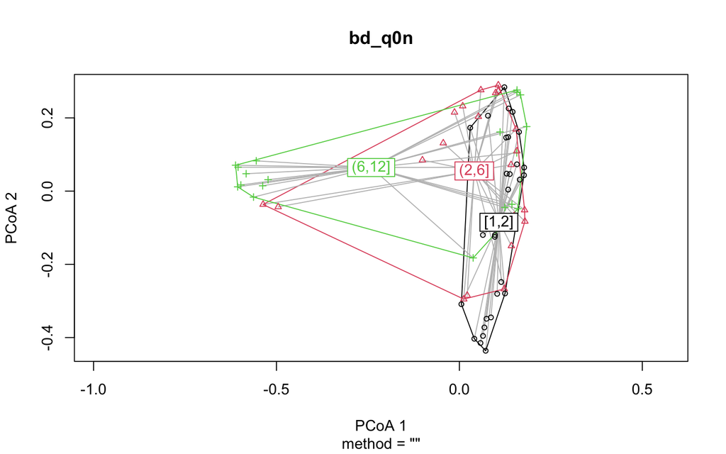

```
Analysis of Variance Table

Response: Distances
          Df   Sum Sq   Mean Sq F value Pr(>F)
Groups     2 0.006265 0.0031326  0.7181 0.4913
Residuals 69 0.301008 0.0043624
```

```
=== Betadisper for q1n beta diversity ===
```

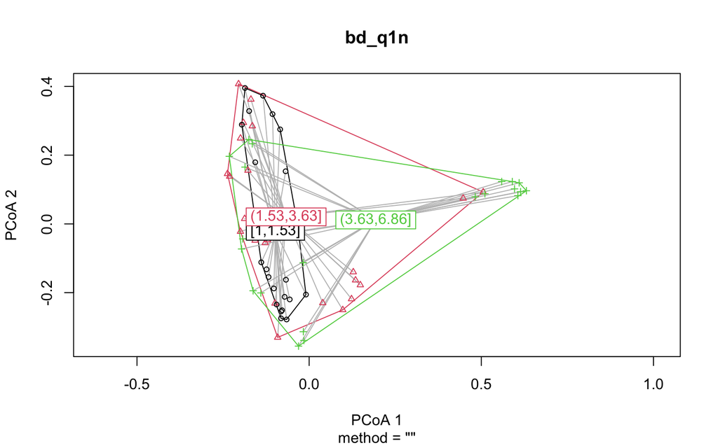

```
Analysis of Variance Table

Response: Distances
          Df   Sum Sq   Mean Sq F value Pr(>F)
Groups     2 0.004427 0.0022135  0.5311 0.5904
Residuals 69 0.287594 0.0041680
```

```
=== Betadisper for q1f beta diversity ===
```

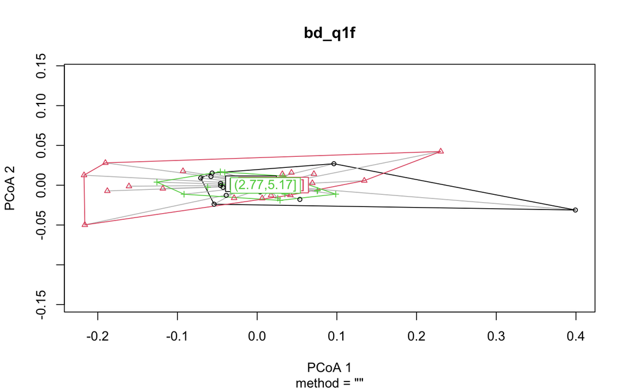

```
Analysis of Variance Table

Response: Distances
          Df   Sum Sq   Mean Sq F value Pr(>F)
Groups     2 0.006565 0.0032824  0.9403 0.3955
Residuals 69 0.240865 0.0034908
```

## 12.9 Correlation tests

**Note:** Test correlations between environmental Hill diversity variables and NMDS ordination axes using Spearman correlation. This is more appropriate than linear regression for non-metric ordination and provides correlation coefficients and significance tests.

```
=== Spearman correlations: Hill diversity vs NMDS axes ===
```

```
--- q0n NMDS ---
```

```
 env_hill_h0_MDS1 :

    Spearman's rank correlation rho

data:  aligned0[[hill_var]] and nmds0n$points[, 1]
S = 42962, p-value = 0.00821
alternative hypothesis: true rho is not equal to 0
sample estimates:
      rho
0.3092535


 env_hill_h0_MDS2 :

    Spearman's rank correlation rho

data:  aligned0[[hill_var]] and nmds0n$points[, 2]
S = 51790, p-value = 0.1601
alternative hypothesis: true rho is not equal to 0
sample estimates:
      rho
0.1673134


 env_hill_h1_MDS1 :

    Spearman's rank correlation rho

data:  aligned0[[hill_var]] and nmds0n$points[, 1]
S = 43840, p-value = 0.01184
alternative hypothesis: true rho is not equal to 0
sample estimates:
      rho
0.2951289


 env_hill_h1_MDS2 :

    Spearman's rank correlation rho

```

[output cut: 15 more lines]

```
sample estimates:
      rho
0.2967086


 env_hill_h2_MDS2 :

    Spearman's rank correlation rho

data:  aligned0[[hill_var]] and nmds0n$points[, 2]
S = 57857, p-value = 0.5604
alternative hypothesis: true rho is not equal to 0
sample estimates:
       rho
0.06976448
```

```
--- q1n NMDS ---
```

```
 env_hill_h0_q1n_MDS1 :

    Spearman's rank correlation rho

data:  aligned1n[[hill_var]] and nmds1n$points[, 1]
S = 46351, p-value = 0.0308
alternative hypothesis: true rho is not equal to 0
sample estimates:
      rho
0.2547671


 env_hill_h0_q1n_MDS2 :

    Spearman's rank correlation rho

data:  aligned1n[[hill_var]] and nmds1n$points[, 2]
S = 57748, p-value = 0.5505
alternative hypothesis: true rho is not equal to 0
sample estimates:
       rho
0.07151128


 env_hill_h1_q1n_MDS1 :

    Spearman's rank correlation rho

data:  aligned1n[[hill_var]] and nmds1n$points[, 1]
S = 53259, p-value = 0.2285
alternative hypothesis: true rho is not equal to 0
sample estimates:
      rho
0.1436878


 env_hill_h1_q1n_MDS2 :

    Spearman's rank correlation rho

```

[output cut: 15 more lines]

```
sample estimates:
     rho
0.129406


 env_hill_h2_q1n_MDS2 :

    Spearman's rank correlation rho

data:  aligned1n[[hill_var]] and nmds1n$points[, 2]
S = 60735, p-value = 0.8447
alternative hypothesis: true rho is not equal to 0
sample estimates:
       rho
0.02348587
```

```
--- q1f NMDS ---
```

```
 env_hill_h0_q1f_MDS1 :

    Spearman's rank correlation rho

data:  aligned1f[[hill_var]] and nmds1f$points[, 1]
S = 57544, p-value = 0.5324
alternative hypothesis: true rho is not equal to 0
sample estimates:
       rho
0.07479161


 env_hill_h0_q1f_MDS2 :

    Spearman's rank correlation rho

data:  aligned1f[[hill_var]] and nmds1f$points[, 2]
S = 53470, p-value = 0.2398
alternative hypothesis: true rho is not equal to 0
sample estimates:
      rho
0.1402999


 env_hill_h1_q1f_MDS1 :

    Spearman's rank correlation rho

data:  aligned1f[[hill_var]] and nmds1f$points[, 1]
S = 60016, p-value = 0.7701
alternative hypothesis: true rho is not equal to 0
sample estimates:
       rho
0.03504343


 env_hill_h1_q1f_MDS2 :

    Spearman's rank correlation rho

```

[output cut: 15 more lines]

```
sample estimates:
       rho
0.03797715


 env_hill_h2_q1f_MDS2 :

    Spearman's rank correlation rho

data:  aligned1f[[hill_var]] and nmds1f$points[, 2]
S = 55620, p-value = 0.3767
alternative hypothesis: true rho is not equal to 0
sample estimates:
      rho
0.1057267
```

## 12.10 Visualization

Associations between environmental α-diversity (Hill h0/h1/h2) and microbiome ordination (NMDS1/2), with fitted vectors and a subset heatmap of Bray–Curtis distances.

**Note:** Create combined scatterplots showing relationships between all environmental Hill diversity metrics and NMDS ordination axes. This provides a comprehensive view of how environmental diversity relates to microbiome β-diversity ordination. Uses loess smoothing instead of linear regression, which is more appropriate for potentially non-linear relationships.

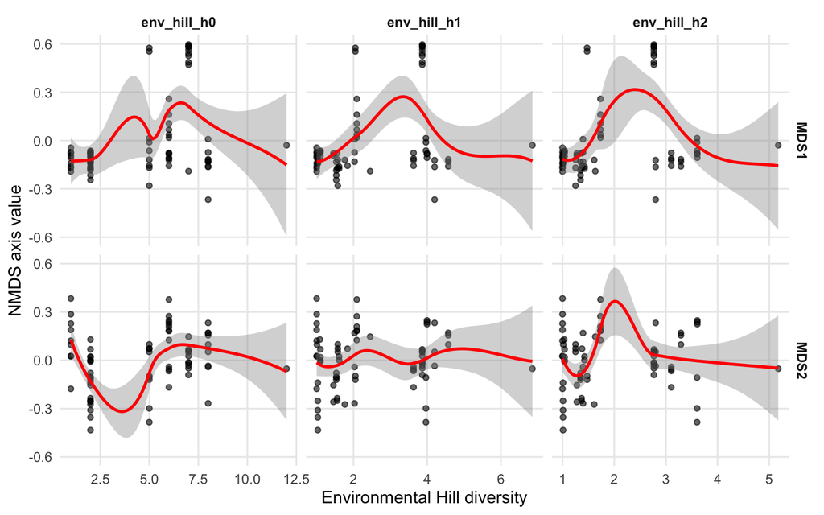

**Note:** Fit environmental Hill diversity vectors (h0, h1, h2) onto the q0 NMDS ordination using envfit. This tests the correlation between environmental variables and ordination axes, displaying significant vectors as arrows on the ordination plot. Improved visualization using ggplot2 for consistency with other plots.

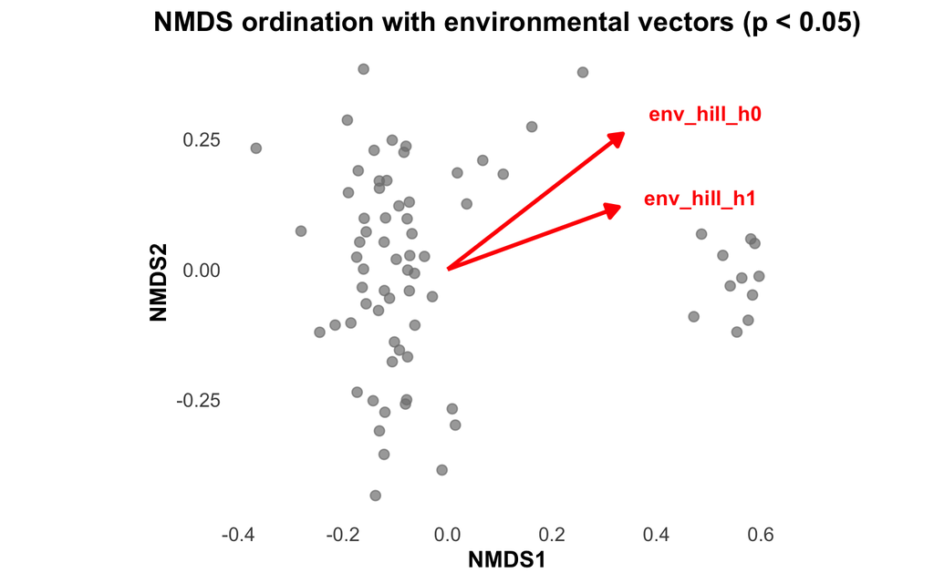

**Note:** Create an improved heatmap visualization of Bray-Curtis dissimilarity matrix with sample grouping information. This shows clustering patterns in microbiome β-diversity and how they relate to environmental Hill diversity groups. Uses all samples (or a representative subset if too large) with grouping annotations.

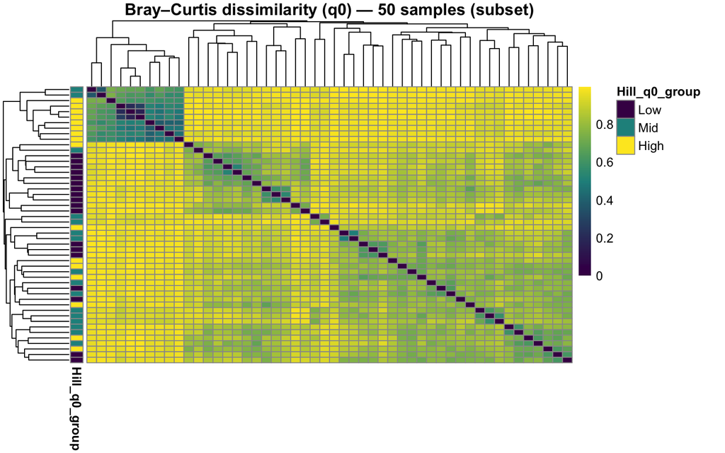

## 12.11 Load data

**Note:** Load sample metadata, genome count data, and Hill diversity metrics from RData files created in previous chapters. Filter out sample EHI01340 which was removed because it could not be mapped to MAGs, ensuring consistency across downstream analyses.

**Note:** Transform Hill diversity data from long to wide format, creating separate columns for each Hill diversity metric (env_hill_h0, env_hill_h1, env_hill_h2). Join with sample metadata to create a combined metadata object for downstream analyses.

## 12.12 Data preparation

**Note:** Create grouping variables for each Hill diversity metric (q0, q1, q2). Split samples into tertiles (Low, Mid, High) based on environmental Hill diversity, then filter to keep only Low and High groups for two-group comparisons. For each q value, create filtered metadata and genome count matrices containing only samples in Low/High groups and genomes present in at least one sample.

```
n filtered_inputs = 3
```

```
q=0 nLow=30 nHigh=20 genomes=1750
q=1 nLow=25 nHigh=22 genomes=1735
q=2 nLow=24 nHigh=17 genomes=1514
```

## 12.13 Structural zeros analysis

**Note:** Identify structural zeros - genomes that are completely absent (zero counts) in one group (Low or High) but present in the other. This is important for ANCOM-BC2 analysis as structural zeros can be handled explicitly. For each q value, calculate which genomes are structurally absent in Low vs High groups and compute group means for genomes that are present in only one group.

**Note:** Create UpSet plot using UpSetR to visualize the intersection of genomes present in Low and High environmental diversity groups. The plot shows unique genomes in each group and shared genomes, with colors indicating group membership.

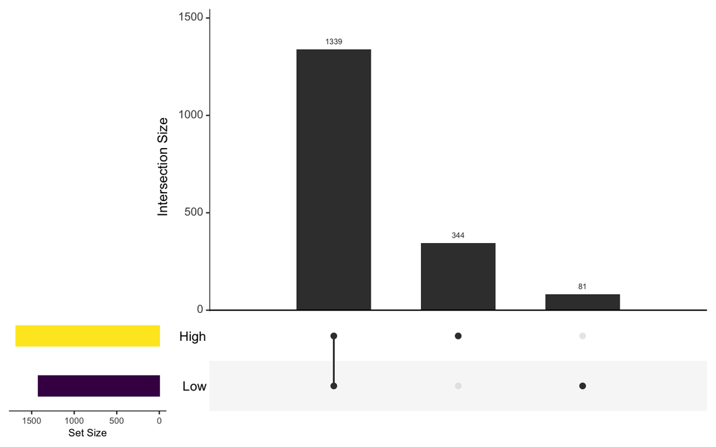

## 12.14 Differential abundance analysis

### 12.14.1 Build phyloseq objects

**Note:** Create phyloseq objects for each q value (q0, q1, q2) containing OTU table (genome counts), taxonomy table, and sample metadata. Counts are kept as integers with zeros allowed, as ANCOM-BC2 can handle zeros without requiring pseudocounts. Sample metadata includes the grouping variable (Low/High) for each Hill diversity metric.

### 12.14.2 Run ANCOM-BC2 analysis

**Note:** Perform ANCOM-BC2 differential abundance testing for each q value, comparing Low vs High environmental diversity groups. The analysis uses structural zero modeling (struc_zero=TRUE) to properly handle genomes absent in one group. Version-adaptive code handles differences between ANCOMBC package versions. Results include log fold-changes, p-values, and adjusted p-values for each genome.

## 12.15 Alternative ANCOM-BC2 analysis with structural zeros

**Note:** Run an alternative ANCOM-BC2 analysis with additional structural zero handling parameters. This analysis uses a random effects model (rand_formula=“~1”) and different parameter settings including Holm p-value adjustment, pseudo-sensitivity analysis, and explicit structural zero detection. This provides a complementary view to the main analysis and may identify additional differentially abundant genomes.

## 12.16 Load data

**Note:** Load sample metadata, genome count data, and Hill diversity metrics from RData files created in previous chapters. These data objects will be used for diversity and abundance analysis comparing samples with low and high environmental diversity.

## 12.17 Data preparation

**Note:** Exclude outlier sample EHI01340 from all datasets. Transform Hill diversity data from long to wide format and join with sample metadata. Choose a Hill diversity metric (default: h1, exponential Shannon) to split samples into tertiles. Filter to keep only Low and High groups (excluding Mid) for two-group comparisons. Ensure sample metadata and genome count matrices are aligned, keeping only samples present in both datasets and genomes with at least one non-zero count.

```r
# --- Configuration: outlier sample to exclude ------------------------------
outlier_sample <- "EHI01340"

# Check if outlier sample exists (may already be excluded in previous chapters)
if (!outlier_sample %in% sample_metadata$sample) {
  message("Note: Outlier sample '", outlier_sample,
          "' not found in sample_metadata (likely already excluded in previous chapters).")
}
```

```
## Note: Outlier sample 'EHI01340' not found in sample_metadata (likely already excluded in previous chapters).
```

```r
# drop the outlier sample everywhere (safe even if already excluded)
sample_metadata <- sample_metadata %>% filter(sample != outlier_sample)

# Optimized: Filter genome counts in one pass - select valid samples and filter zero rows
valid_sample_cols <- intersect(sample_metadata$sample, colnames(genome_counts_filt))
genome_counts_filt <- genome_counts_filt %>%
  select(genome, all_of(valid_sample_cols)) %>%
  filter(rowSums(across(-genome, ~ .x != 0), na.rm = TRUE) > 0)

# Validate filtering results
if (nrow(sample_metadata) == 0) {
  stop("Error: No samples remaining after filtering. Check sample_metadata.")
}
if (nrow(genome_counts_filt) == 0) {
  stop("Error: No genomes remaining after filtering. Check genome_counts_filt.")
}

# --- choose which Hill order to split on ----------------------------------
# use "h1" by default (exp-Shannon). Change to "h0" or "h2" if you prefer.
q_choice <- "h1"

# Validate q_choice format
valid_q_choices <- c("h0", "h1", "h2")
if (!q_choice %in% valid_q_choices) {
  stop("Error: q_choice must be one of: ", paste(valid_q_choices, collapse = ", "))
}

# Validate hill_long exists and has data
if (!exists("hill_long") || nrow(hill_long) == 0) {
  stop("Error: hill_long is missing or empty.")
}

# Optimized: Build Hill-wide and join with metadata in one pipeline
hill_col <- paste0("env_hill_", q_choice)

hill_wide <- hill_long %>%
  filter(id != outlier_sample) %>%
  rename(sample = id) %>%
  pivot_wider(id_cols = sample,
              names_from = q,
              values_from = value,
              names_glue = "env_hill_{q}")

# Validate pivot_wider results
if (!hill_col %in% colnames(hill_wide)) {
  stop("Error: Hill diversity column '", hill_col, "' not found after pivot_wider. ",
       "Available columns: ", paste(colnames(hill_wide), collapse = ", "))
}

# Optimized: Join and filter missing Hill data in one step
meta_hill <- sample_metadata %>%
  left_join(hill_wide, by = "sample") %>%
  filter(!is.na(.data[[hill_col]]))  # Remove samples with missing Hill diversity data

# Report if any samples were excluded
n_excluded_hill <- nrow(sample_metadata) - nrow(meta_hill)
if (n_excluded_hill > 0) {
  warning("Found ", n_excluded_hill, " samples with missing Hill diversity data. These were excluded.")
}

# Validate we have enough samples for tertiles (need at least 3)
if (nrow(meta_hill) < 3) {
  stop("Error: Insufficient samples (", nrow(meta_hill), ") for creating tertiles. Need at least 3 samples.")
}

group_col <- paste0("env_group_q", substr(q_choice, 2, 2))  # env_group_q1, etc.

# tertiles → keep only Low/High (drop Mid) and fix factor order Low < High
# Use tryCatch to handle edge cases in cut_number
meta_hill <- tryCatch({
  meta_hill %>%
    mutate(
      !!group_col := ggplot2::cut_number(.data[[hill_col]],
                                        3, labels = c("Low","Mid","High"))
    ) %>%
    filter(.data[[group_col]] %in% c("Low","High")) %>%
    mutate(!!group_col := factor(.data[[group_col]], levels = c("Low","High")))
}, error = function(e) {
  stop("Error creating tertiles with cut_number: ", e$message,
       ". This may occur if there are too few unique values in ", hill_col)
})

# Validate group creation
if (nrow(meta_hill) == 0) {
  stop("Error: No samples remaining after filtering to Low/High groups.")
}

# Validate group creation
group_counts <- table(meta_hill[[group_col]], useNA = "no")
if (any(group_counts == 0)) {
  stop("Error: One or both groups (Low/High) are empty after filtering. ",
       paste(names(group_counts), group_counts, sep = "=", collapse = ", "))
}

# Optimized: Keep only samples present in both datasets in one pass
valid_samples <- intersect(meta_hill$sample, colnames(genome_counts_filt))
if (length(valid_samples) == 0) {
  stop("Error: No overlapping samples between meta_hill and genome_counts_filt.")
}

# Filter both datasets to valid samples
meta_hill <- meta_hill %>% filter(sample %in% valid_samples)
genome_counts_filt <- genome_counts_filt %>%
  select(genome, all_of(valid_samples)) %>%
  # Re-filter genomes to ensure they're still present after sample filtering
  filter(rowSums(across(-genome, ~ .x != 0), na.rm = TRUE) > 0)

# Final validation
if (nrow(meta_hill) == 0) {
  stop("Error: No samples remaining after final filtering.")
}

cat("N Low / High = ",
    sum(meta_hill[[group_col]] == "Low"), " / ",
    sum(meta_hill[[group_col]] == "High"), "\n", sep = "")
```

```
## N Low / High = 25 / 22
```

## 12.18 Structural zeros analysis

```
Found  493  genomes with structural zeros.
```

[figure not shown]

## 12.19 Taxonomic aggregation of structural zeros

```
### Structural zeros by phylum


|phylum               |present | n_genomes| mean_abundance| median_abundance|
|:--------------------|:-------|---------:|--------------:|----------------:|
|p__Bacillota_A       |High    |       274|          1.254|            0.756|
|p__Bacillota_A       |Low     |       105|          1.019|            0.511|
|p__Bacteroidota      |High    |        24|          6.577|            1.446|
|p__Bacillota         |High    |        18|          0.734|            0.443|
|p__Cyanobacteriota   |Low     |        14|          0.651|            0.451|
|p__Bacillota         |Low     |        10|          0.613|            0.558|
|p__Bacteroidota      |Low     |         7|          1.914|            0.793|
|p__Cyanobacteriota   |High    |         7|          0.454|            0.483|
|p__Synergistota      |High    |         6|          2.829|            1.643|
|p__Actinomycetota    |High    |         5|          0.608|            0.640|
|p__Campylobacterota  |High    |         5|          2.041|            0.794|
|p__Bacillota_C       |High    |         3|          1.962|            2.213|
|p__Pseudomonadota    |High    |         3|          1.457|            1.862|
|p__Pseudomonadota    |Low     |         3|          0.122|            0.116|
|p__Actinomycetota    |Low     |         2|          3.580|            3.580|
|p__Spirochaetota     |High    |         2|          3.369|            3.369|
|p__Verrucomicrobiota |High    |         2|          1.081|            1.081|
|p__Campylobacterota  |Low     |         1|          0.106|            0.106|
|p__Desulfobacterota  |High    |         1|          2.733|            2.733|
|p__Thermoplasmatota  |High    |         1|          3.805|            3.805|
```

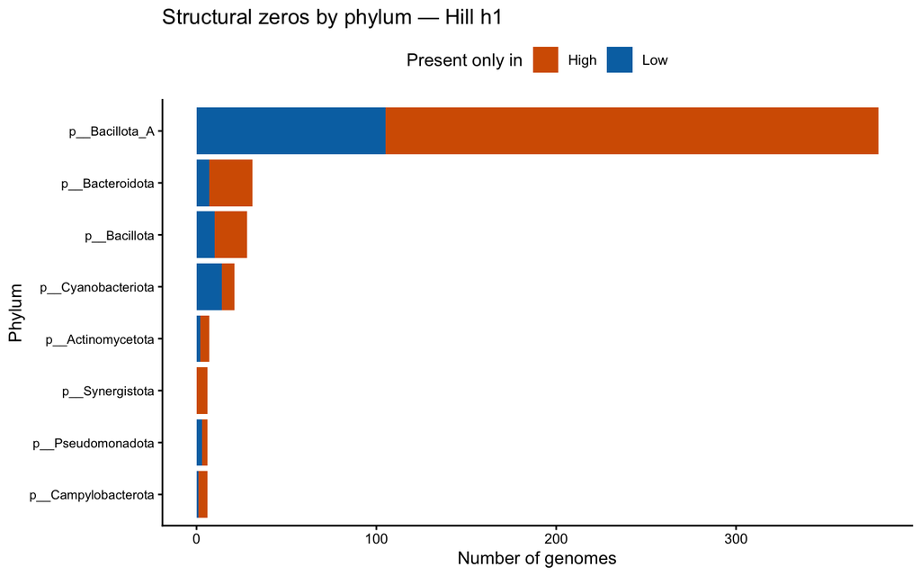

## 12.20 Microbiome diversity comparison

**Note:** Calculate microbiome alpha diversity metrics (richness, neutral, phylogenetic) for all samples using Hill numbers. Validate that the phylogenetic tree exists and prune it to match genomes present in the filtered count data. Calculate richness (q=0, species count), neutral diversity (q=1, Shannon diversity), and phylogenetic diversity (q=1 with tree) for each sample. Merge all diversity metrics and join with sample metadata including environmental diversity groups.

```
Calculated microbiome alpha diversity for 47 samples.
```

**Note:** Create boxplots comparing microbiome alpha diversity metrics between Low and High environmental diversity groups. Perform Wilcoxon rank-sum tests to assess statistical significance of differences. Visualize results with boxplots showing distributions and statistical test results.

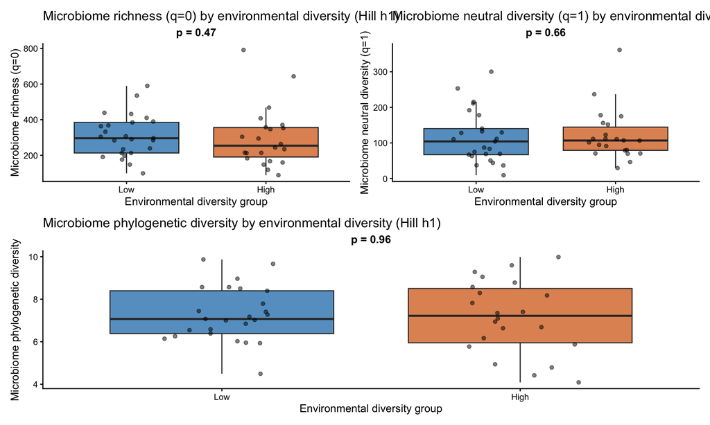

## 12.21 Correlation analysis

**Note:** Test correlations between environmental Hill diversity and microbiome alpha diversity metrics. This analysis directly quantifies the relationship between environmental diversity and microbiome diversity using Spearman correlation, which is appropriate for potentially non-linear relationships. Create scatter plots with regression lines to visualize these relationships.

```
### Spearman correlations: Environmental Hill diversity vs Microbiome alpha diversity

 richness :
  rho = 0.058 , p = 0.701 , n = 47

 neutral :
  rho = 0.171 , p = 0.25 , n = 47

 phylogenetic :
  rho = -0.019 , p = 0.9 , n = 47
```

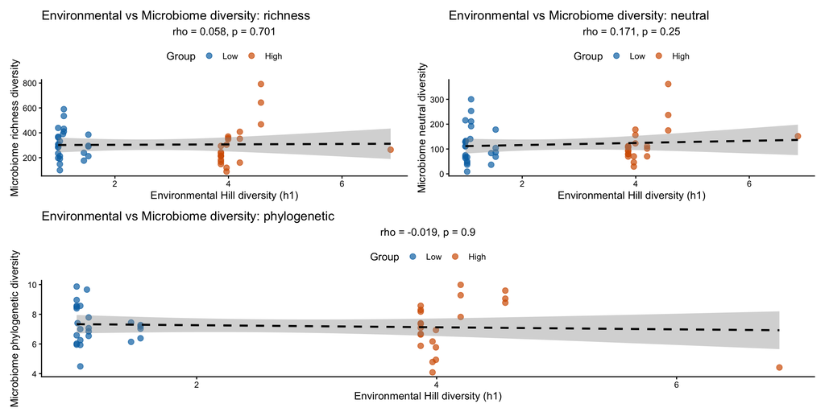